# Intro to Data Science (Non-Technical Background, R) - Session19

Goran S. Milovanović, PhD

DataKolektiv, Chief Scientist & Owner; Data Scientist for Wikidata, WMDE

# Session 19. Cross-validation in classification problems. An introduction to Decision Trees: complicated classification problems and powerful solutions. Postpruning of a Decision Tree model.

**Feedback** should be send to `goran.milovanovic@datakolektiv.com`. These notebooks accompany the Intro to Data Science: Non-Technical Background course 2020/21.

### What do we want to do today?

We will first consider cross-validation in classification problems and contrast it with previously introduced approaches to model selection. Then we begin to go beyond Linear Models: we will introduce **Decision Trees** for classification and regression problems. In this session we go for an intuitive and practical approach to Decision Trees in R; in the next session we will introduce the basic elements of **Information Theory** and dig deeper into the theory of Decision Trees and even more powerful Random Forests.

### 0. Setup

```r
install.packages('rpart')
install.packages ('rpart.plot')
```

Grab the `HR_comma_sep.csv` dataset from the [Kaggle](https://www.kaggle.com/liujiaqi/hr-comma-sepcsv) and place it in your `_data` directory for this session.

```r
dataDir <- paste0(getwd(), "/_data/")
library(tidyverse)
library(data.table)
library(rpart)
library(rpart.plot)
```

### 1. Cross-Validation in Classification Problems

Consider the `HR_comma_sep.csv` dataset:

```r
dataSet <- read.csv(paste0('_data/', 'HR_comma_sep.csv'),
                    header = T,
                    check.names = F,
                    stringsAsFactors = F)
head(dataSet)
```

|  | satisfaction_level | last_evaluation | number_project | average_montly_hours | time_spend_company | Work_accident | left | promotion_last_5years | sales | salary |
| --- | --- | --- | --- | --- | --- | --- | --- | --- | --- | --- |
| 1 | 0.38 | 0.53 | 2 | 157 | 3 | 0 | 1 | 0 | sales | low |
| 2 | 0.80 | 0.86 | 5 | 262 | 6 | 0 | 1 | 0 | sales | medium |
| 3 | 0.11 | 0.88 | 7 | 272 | 4 | 0 | 1 | 0 | sales | medium |
| 4 | 0.72 | 0.87 | 5 | 223 | 5 | 0 | 1 | 0 | sales | low |
| 5 | 0.37 | 0.52 | 2 | 159 | 3 | 0 | 1 | 0 | sales | low |
| 6 | 0.41 | 0.50 | 2 | 153 | 3 | 0 | 1 | 0 | sales | low |

```r
table(dataSet$left)
```

```
    0     1
11428  3571
```

The task is to predict the value of `left` - whether the employee has left the company or not - from a set of predictors encompassing the following:

```r
glimpse(dataSet)
```

```
Rows: 14,999
Columns: 10
$ satisfaction_level    <dbl> 0.38, 0.80, 0.11, 0.72, 0.37, 0.41, 0.10, 0.92, 0.89, 0.42, 0.45, 0.11, 0.84, 0.41, 0.3…
$ last_evaluation       <dbl> 0.53, 0.86, 0.88, 0.87, 0.52, 0.50, 0.77, 0.85, 1.00, 0.53, 0.54, 0.81, 0.92, 0.55, 0.5…
$ number_project        <int> 2, 5, 7, 5, 2, 2, 6, 5, 5, 2, 2, 6, 4, 2, 2, 2, 2, 4, 2, 5, 6, 2, 6, 2, 2, 5, 4, 2, 2, …
$ average_montly_hours  <int> 157, 262, 272, 223, 159, 153, 247, 259, 224, 142, 135, 305, 234, 148, 137, 143, 160, 25…
$ time_spend_company    <int> 3, 6, 4, 5, 3, 3, 4, 5, 5, 3, 3, 4, 5, 3, 3, 3, 3, 6, 3, 5, 4, 3, 4, 3, 3, 5, 5, 3, 3, …
$ Work_accident         <int> 0, 0, 0, 0, 0, 0, 0, 0, 0, 0, 0, 0, 0, 0, 0, 0, 0, 0, 1, 0, 0, 0, 0, 0, 0, 0, 0, 0, 0, …
$ left                  <int> 1, 1, 1, 1, 1, 1, 1, 1, 1, 1, 1, 1, 1, 1, 1, 1, 1, 1, 1, 1, 1, 1, 1, 1, 1, 1, 1, 1, 1, …
$ promotion_last_5years <int> 0, 0, 0, 0, 0, 0, 0, 0, 0, 0, 0, 0, 0, 0, 0, 0, 0, 0, 1, 0, 0, 0, 0, 0, 0, 0, 0, 0, 0, …
$ sales                 <chr> "sales", "sales", "sales", "sales", "sales", "sales", "sales", "sales", "sales", "sales…
$ salary                <chr> "low", "medium", "medium", "low", "low", "low", "low", "low", "low", "low", "low", "low…
```

- **satisfaction_level**: a measure of employee’s level of satisfaction
- **last_evaluation**: the result of a last evaluation
- **number_projects**: in how many projects did the employee took part
- **average_monthly_hours**: how working hours monthly on average
- **time_spend_company**: for how long is the employee with us
- **Work_accident**: any work accidents?
- **promotion_last_5years**: did the promotion occur in the last five years?
- **sales**: department (sales, accounting, hr, technical, support, management, IT, product_mng, marketing, RandD)
- **salary**: salary class (low, medium, high)

Let’s formulate a Binomial Logistic Regression model to try to predict `left` from `satisfaction_level`, `last_evaluation`, `sales`, and `salary`:

```r
# - setups
dataSet$left <- factor(dataSet$left,
                       levels = c(0, 1))
dataSet$salary <- factor(dataSet$salary)
dataSet$salary <- relevel(dataSet$salary,
                          ref = 'high')
dataSet$sales <- factor(dataSet$sales)
dataSet$sales <- relevel(dataSet$sales,
                         ref = 'RandD')
# - model
blr_model1 <- glm(left ~ satisfaction_level + last_evaluation + sales + salary,
                  data = dataSet,
                  family = "binomial")
modelsummary <- summary(blr_model1)
print(modelsummary)
```

```
Call:
glm(formula = left ~ satisfaction_level + last_evaluation + sales +
    salary, family = "binomial", data = dataSet)

Deviance Residuals:
    Min       1Q   Median       3Q      Max
-1.7093  -0.6970  -0.4741  -0.1928   2.7917

Coefficients:
                   Estimate Std. Error z value Pr(>|z|)
(Intercept)        -1.46022    0.18380  -7.945 1.95e-15 ***
satisfaction_level -3.87156    0.08923 -43.387  < 2e-16 ***
last_evaluation     0.53218    0.12208   4.359 1.31e-05 ***
salesaccounting     0.67072    0.14023   4.783 1.73e-06 ***
saleshr             0.88149    0.13928   6.329 2.47e-10 ***
salesIT             0.49930    0.13124   3.804 0.000142 ***
salesmanagement     0.26267    0.16531   1.589 0.112068
salesmarketing      0.65029    0.13890   4.682 2.84e-06 ***
salesproduct_mng    0.51352    0.13853   3.707 0.000210 ***
salessales          0.62675    0.11422   5.487 4.08e-08 ***
salessupport        0.66090    0.12001   5.507 3.65e-08 ***
salestechnical      0.67753    0.11769   5.757 8.57e-09 ***
salarylow           1.77870    0.12287  14.476  < 2e-16 ***
salarymedium        1.28847    0.12400  10.391  < 2e-16 ***
---
Signif. codes:  0 ‘***’ 0.001 ‘**’ 0.01 ‘*’ 0.05 ‘.’ 0.1 ‘ ’ 1

(Dispersion parameter for binomial family taken to be 1)

    Null deviance: 16465  on 14998  degrees of freedom
Residual deviance: 13733  on 14985  degrees of freedom
AIC: 13761

Number of Fisher Scoring iterations: 5
```

And take a look at the regression coefficients:

```r
exp(coefficients(blr_model1))
```

```
       (Intercept) satisfaction_level    last_evaluation    salesaccounting            saleshr            salesIT
        0.23218577         0.02082584         1.70263484         1.95564264         2.41448902         1.64756456
   salesmanagement     salesmarketing   salesproduct_mng         salessales       salessupport     salestechnical
        1.30039267         1.91608809         1.67116051         1.87152647         1.93652695         1.96900961
         salarylow       salarymedium
        5.92213412         3.62722234
```

The Akaike Information Criterion is:

```r
blr_model1$aic
```

```
[1] 13761.14
```

Now consider a model encompassing all predictors from the `HR_comma_sep.csv`:

```r
# - setups
dataSet$Work_accident <- factor(dataSet$Work_accident,
                                levels = c(0, 1))
dataSet$promotion_last_5years <- factor(dataSet$promotion_last_5years,
                                        levels = c(0, 1))

# - model
blr_model2 <- glm(left ~ .,
                  data = dataSet,
                  family = "binomial")
modelsummary <- summary(blr_model2)
print(modelsummary)
```

```
Call:
glm(formula = left ~ ., family = "binomial", data = dataSet)

Deviance Residuals:
    Min       1Q   Median       3Q      Max
-2.2248  -0.6645  -0.4026  -0.1177   3.0688

Coefficients:
                         Estimate Std. Error z value Pr(>|z|)
(Intercept)            -2.0586521  0.2035965 -10.111  < 2e-16 ***
satisfaction_level     -4.1356889  0.0980538 -42.178  < 2e-16 ***
last_evaluation         0.7309032  0.1491787   4.900 9.61e-07 ***
number_project         -0.3150787  0.0213248 -14.775  < 2e-16 ***
average_montly_hours    0.0044603  0.0005161   8.643  < 2e-16 ***
time_spend_company      0.2677537  0.0155736  17.193  < 2e-16 ***
Work_accident1         -1.5298283  0.0895473 -17.084  < 2e-16 ***
promotion_last_5years1 -1.4301364  0.2574958  -5.554 2.79e-08 ***
salesaccounting         0.5823659  0.1448848   4.020 5.83e-05 ***
saleshr                 0.8147438  0.1439439   5.660 1.51e-08 ***
salesIT                 0.4016480  0.1355936   2.962  0.00306 **
salesmanagement         0.1339423  0.1704829   0.786  0.43206
salesmarketing          0.5702777  0.1445326   3.946 7.96e-05 ***
salesproduct_mng        0.4291129  0.1428822   3.003  0.00267 **
salessales              0.5435800  0.1181590   4.600 4.22e-06 ***
salessupport            0.6323910  0.1241337   5.094 3.50e-07 ***
salestechnical          0.6525123  0.1217267   5.360 8.30e-08 ***
salarylow               1.9440627  0.1286272  15.114  < 2e-16 ***
salarymedium            1.4132244  0.1293534  10.925  < 2e-16 ***
---
Signif. codes:  0 ‘***’ 0.001 ‘**’ 0.01 ‘*’ 0.05 ‘.’ 0.1 ‘ ’ 1

(Dispersion parameter for binomial family taken to be 1)

    Null deviance: 16465  on 14998  degrees of freedom
Residual deviance: 12850  on 14980  degrees of freedom
AIC: 12888

Number of Fisher Scoring iterations: 5
```

```r
exp(coefficients(blr_model2))
```

```
           (Intercept)     satisfaction_level        last_evaluation         number_project   average_montly_hours
            0.12762588             0.01599164             2.07695560             0.72973146             1.00447026
    time_spend_company         Work_accident1 promotion_last_5years1        salesaccounting                saleshr
            1.30702513             0.21657284             0.23927628             1.79026897             2.25859684
               salesIT        salesmanagement         salesmarketing       salesproduct_mng             salessales
            1.49428520             1.14332679             1.76875818             1.53589447             1.72216110
          salessupport         salestechnical              salarylow           salarymedium
            1.88210526             1.92035920             6.98708012             4.10918362
```

The Akaike Information Criterion is:

```r
blr_model2$aic
```

```
[1] 12887.9
```

Let’s cross-validate our `blr_model1` and `blr_model2` now. We will perform the *k-fold* CV in the following way:

- define four folds in the dataSet by randomly assigning each observation to fold 1, 2, 3, or 4;
- for each `i` in `folds`: estimate the model on the remaining *dataSet[-i, ]* folds taken together
- predict the observations in fold `i` from the fitted model,
- compute model accuracy, FA rate, Hit rate for fold `i`,
- observe the average accuracy (ROC) across all four folds.

Here we go: define folds first.

```r
dataSet$fold <- sample(1:4, size = dim(dataSet)[1], replace = T)
table(dataSet$fold)
```

```
   1    2    3    4
3647 3762 3790 3800
```

First for the narrower model:

```r
cv1 <- lapply(1:4, function(x) {

  # - test and train datasets
  test <- dataSet %>%
    dplyr::filter(fold == x) %>%
    dplyr::select(-fold)
  train <- dataSet %>%
    dplyr::filter(fold != x) %>%
    dplyr::select(-fold)

  # - model on the training dataset
  blrModel <- glm(left ~ satisfaction_level + last_evaluation + sales + salary,
                  data = train,
                  family = "binomial")

  # - predict on the test dataset
  predictions <- predict(blrModel,
                         newdata = test,
                         type = "response")
  predictions <- ifelse(predictions > .5, 1, 0)

  # - ROC analysis
  acc <- sum(test$left == predictions)
  acc <- acc/dim(test)[1]
  hit <- sum(test$left == 1 & predictions == 1)
  hit <- hit/sum(test$left == 1)
  fa <- sum(test$left == 0 & predictions == 1)
  fa <- fa/sum(test$left == 0)
  return(data.frame(acc, hit, fa))
})

cv1 <- rbindlist(cv1)
cv1$fold <- 1:4
cv1 <- tidyr::pivot_longer(cv1,
                           cols = -fold,
                           names_to = 'measure',
                           values_to = 'value')
cv1$model <- 1
print(cv1)
```

| fold | measure | value | model |
| --- | --- | --- | --- |
| 1 | acc | 0.77049630 | 1 |
| 1 | hit | 0.25736961 | 1 |
| 1 | fa | 0.06582278 | 1 |
| 2 | acc | 0.77405635 | 1 |
| 2 | hit | 0.25963719 | 1 |
| 2 | fa | 0.06840278 | 1 |
| 3 | acc | 0.77440633 | 1 |
| 3 | hit | 0.27412281 | 1 |
| 3 | fa | 0.06706046 | 1 |
| 4 | acc | 0.78105263 | 1 |

[output cut: 2 more lines]

Now for the full model:

```r
cv2 <- lapply(1:4, function(x) {
  test <- dataSet %>%
    dplyr::filter(fold == x) %>%
    dplyr::select(-fold)
  train <- dataSet %>%
    dplyr::filter(fold != x) %>%
    dplyr::select(-fold)
  blrModel <- glm(left ~ .,
                  data = train,
                  family = "binomial")
  predictions <- predict(blrModel,
                         newdata = test,
                         type = "response")
  predictions <- ifelse(predictions > .5, 1, 0)
  acc <- sum(test$left == predictions)
  acc <- acc/dim(test)[1]
  hit <- sum(test$left == 1 & predictions == 1)
  hit <- hit/sum(test$left == 1)
  fa <- sum(test$left == 0 & predictions == 1)
  fa <- fa/sum(test$left == 0)
  return(data.frame(acc, hit, fa))
})
cv2 <- rbindlist(cv2)
cv2$fold <- 1:4
cv2 <- tidyr::pivot_longer(cv2,
                           cols = -fold,
                           names_to = 'measure',
                           values_to = 'value')
cv2$model <- 2
print(cv2)
```

| fold | measure | value | model |
| --- | --- | --- | --- |
| 1 | acc | 0.78502879 | 2 |
| 1 | hit | 0.34126984 | 2 |
| 1 | fa | 0.07341772 | 2 |
| 2 | acc | 0.79027113 | 2 |
| 2 | hit | 0.35941043 | 2 |
| 2 | fa | 0.07777778 | 2 |
| 3 | acc | 0.80000000 | 2 |
| 3 | hit | 0.39802632 | 2 |
| 3 | fa | 0.07261987 | 2 |
| 4 | acc | 0.78552632 | 2 |

[output cut: 2 more lines]

Compare:

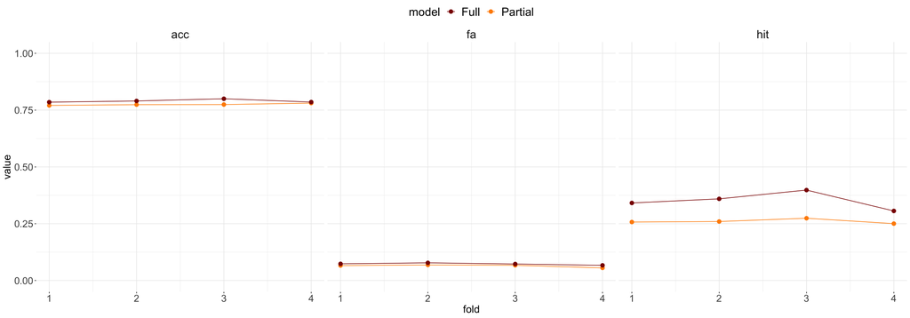

```r
modelSelection <- rbind(cv1, cv2)
modelSelection$model <- ifelse(modelSelection$model == 1,
                               "Partial", "Full")
modelSelection$model <- factor(modelSelection$model)
ggplot(data = modelSelection,
       aes(x = fold,
           y = value,
           group = model,
           color = model,
           fill = model)) +
  geom_path(size = .5) +
  geom_point(size = 3) +
  scale_color_manual(values = c('darkred', 'darkorange')) +
  ylim(0, 1) +
  facet_wrap(~measure) +
  theme_bw() +
  theme(panel.border = element_blank()) +
  theme(legend.text = element_text(size = 20)) +
  theme(legend.title = element_text(size = 20)) +
  theme(legend.position = "top") +
  theme(strip.background = element_blank()) +
  theme(strip.text = element_text(size = 20)) +
  theme(axis.title.x = element_text(size = 18)) +
  theme(axis.title.y = element_text(size = 18)) +
  theme(axis.text.x = element_text(size = 17)) +
  theme(axis.text.y = element_text(size = 17))
```

The average ROC from k-fold CV for both models:

```r
modelSelection %>%
  dplyr::select(-fold) %>%
  dplyr::group_by(model, measure) %>%
  dplyr::summarise(mean = round(mean(value), 5)) %>%
  tidyr::pivot_wider(id_cols = model,
                     names_from = 'measure',
                     values_from = 'mean')
```

| model | acc | fa | hit |
| --- | --- | --- | --- |
| Full | 0.79021 | 0.07265 | 0.35121 |
| Partial | 0.77500 | 0.06418 | 0.26035 |

Suppose we set the decision trashold to be `p = .2`. First for the narrow model:

```r
cv1 <- lapply(1:4, function(x) {

  # - test and train datasets
  test <- dataSet %>%
    dplyr::filter(fold == x) %>%
    dplyr::select(-fold)
  train <- dataSet %>%
    dplyr::filter(fold != x) %>%
    dplyr::select(-fold)

  # - model on the training dataset
  blrModel <- glm(left ~ satisfaction_level + last_evaluation + sales + salary,
                  data = train,
                  family = "binomial")

  # - predict on the test dataset
  predictions <- predict(blrModel,
                         newdata = test,
                         type = "response")
  predictions <- ifelse(predictions > .2, 1, 0)

  # - ROC analysis
  acc <- sum(test$left == predictions)
  acc <- acc/dim(test)[1]
  hit <- sum(test$left == 1 & predictions == 1)
  hit <- hit/sum(test$left == 1)
  fa <- sum(test$left == 0 & predictions == 1)
  fa <- fa/sum(test$left == 0)
  return(data.frame(acc, hit, fa))
})

cv1 <- rbindlist(cv1)
cv1$fold <- 1:4
cv1 <- tidyr::pivot_longer(cv1,
                           cols = -fold,
                           names_to = 'measure',
                           values_to = 'value')
cv1$model <- 1
```

Now for the full model, decision treshold is `p = .2`:

```r
cv2 <- lapply(1:4, function(x) {
  test <- dataSet %>%
    dplyr::filter(fold == x) %>%
    dplyr::select(-fold)
  train <- dataSet %>%
    dplyr::filter(fold != x) %>%
    dplyr::select(-fold)
  blrModel <- glm(left ~ .,
                  data = train,
                  family = "binomial")
  predictions <- predict(blrModel,
                         newdata = test,
                         type = "response")
  predictions <- ifelse(predictions > .2, 1, 0)
  acc <- sum(test$left == predictions)
  acc <- acc/dim(test)[1]
  hit <- sum(test$left == 1 & predictions == 1)
  hit <- hit/sum(test$left == 1)
  fa <- sum(test$left == 0 & predictions == 1)
  fa <- fa/sum(test$left == 0)
  return(data.frame(acc, hit, fa))
})
cv2 <- rbindlist(cv2)
cv2$fold <- 1:4
cv2 <- tidyr::pivot_longer(cv2,
                           cols = -fold,
                           names_to = 'measure',
                           values_to = 'value')
cv2$model <- 2
```

Compare:

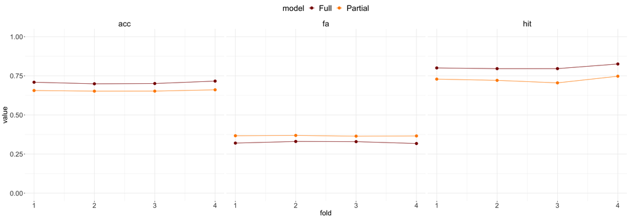

```r
modelSelection <- rbind(cv1, cv2)
modelSelection$model <- ifelse(modelSelection$model == 1,
                               "Partial", "Full")
modelSelection$model <- factor(modelSelection$model)
ggplot(data = modelSelection,
       aes(x = fold,
           y = value,
           group = model,
           color = model,
           fill = model)) +
  geom_path(size = .5) +
  geom_point(size = 3) +
  scale_color_manual(values = c('darkred', 'darkorange')) +
  ylim(0, 1) +
  facet_wrap(~measure) +
  theme_bw() +
  theme(panel.border = element_blank()) +
  theme(legend.text = element_text(size = 20)) +
  theme(legend.title = element_text(size = 20)) +
  theme(legend.position = "top") +
  theme(strip.background = element_blank()) +
  theme(strip.text = element_text(size = 20)) +
  theme(axis.title.x = element_text(size = 18)) +
  theme(axis.title.y = element_text(size = 18)) +
  theme(axis.text.x = element_text(size = 17)) +
  theme(axis.text.y = element_text(size = 17))
```

Across a range of decision criteria, `dec_criterion <- seq(.01, .99, .01)`, initial model with four predictors:

```r
cv1 <- lapply(1:4, function(x) {

  # - test and train datasets
  test <- dataSet %>%
    dplyr::filter(fold == x) %>%
    dplyr::select(-fold)
  train <- dataSet %>%
    dplyr::filter(fold != x) %>%
    dplyr::select(-fold)

  # - model on the training dataset
  blrModel <- glm(left ~ satisfaction_level + last_evaluation + sales + salary,
                  data = train,
                  family = "binomial")

  # - predict on the test dataset
  predictions <- predict(blrModel,
                         newdata = test,
                         type = "response")
  dec_criterion <- seq(.01, .99, .01)
  predictions <- lapply(dec_criterion, function(y) {
    return(
      ifelse(predictions > y, 1, 0)
    )
  })
  predictions <- t(Reduce(rbind, predictions))
  roc <- apply(predictions, 2, function(y) {
    # - ROC analysis
    acc <- sum(test$left == y)
    acc <- acc/dim(test)[1]
    hit <- sum(test$left == 1 & y == 1)
    hit <- hit/sum(test$left == 1)
    fa <- sum(test$left == 0 & y == 1)
    fa <- fa/sum(test$left == 0)
    return(data.frame(acc, hit, fa))
  })
  roc <- rbindlist(roc)
  roc$dec_criterion <- dec_criterion
  roc$fold <- x
  return(roc)
})

cv1 <- rbindlist(cv1)
cv1 <- cv1 %>%
  dplyr::group_by(dec_criterion) %>%
  dplyr::summarise(acc = mean(acc),
                   hit = mean(hit),
                   fa = mean(fa))
cv1 <- tidyr::pivot_longer(cv1,
                           cols = -dec_criterion,
                           names_to = 'measure',
                           values_to = 'value')
cv1$model <- 1
```

For the full model, `dec_criterion <- seq(.01, .99, .01)`:

```r
cv2 <- lapply(1:4, function(x) {

  # - test and train datasets
  test <- dataSet %>%
    dplyr::filter(fold == x) %>%
    dplyr::select(-fold)
  train <- dataSet %>%
    dplyr::filter(fold != x) %>%
    dplyr::select(-fold)

  # - model on the training dataset
  blrModel <- glm(left ~ .,
                  data = train,
                  family = "binomial")

  # - predict on the test dataset
  predictions <- predict(blrModel,
                         newdata = test,
                         type = "response")
  dec_criterion <- seq(.01, .99, .01)
  predictions <- lapply(dec_criterion, function(y) {
    return(
      ifelse(predictions > y, 1, 0)
    )
  })
  predictions <- t(Reduce(rbind, predictions))
  roc <- apply(predictions, 2, function(y) {
    # - ROC analysis
    acc <- sum(test$left == y)
    acc <- acc/dim(test)[1]
    hit <- sum(test$left == 1 & y == 1)
    hit <- hit/sum(test$left == 1)
    fa <- sum(test$left == 0 & y == 1)
    fa <- fa/sum(test$left == 0)
    return(data.frame(acc, hit, fa))
  })
  roc <- rbindlist(roc)
  roc$dec_criterion <- dec_criterion
  roc$fold <- x
  return(roc)
})

cv2 <- rbindlist(cv2)
cv2 <- cv2 %>%
  dplyr::group_by(dec_criterion) %>%
  dplyr::summarise(acc = mean(acc),
                   hit = mean(hit),
                   fa = mean(fa))
cv2 <- tidyr::pivot_longer(cv2,
                           cols = -dec_criterion,
                           names_to = 'measure',
                           values_to = 'value')
cv2$model <- 2
```

Compare ROC curves:

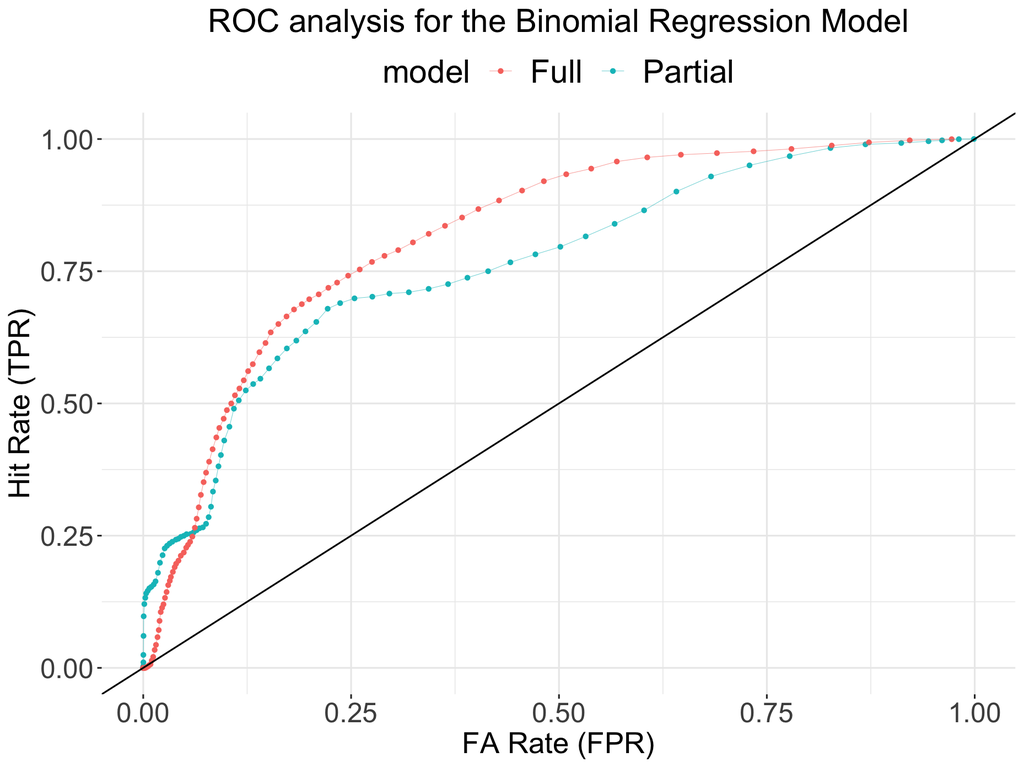

```r
ROC_results <- rbind(cv1, cv2)
ROC_results$model <- ifelse(ROC_results$model == 1,
                               "Partial", "Full")
ROC_results <- ROC_results %>%
  pivot_wider(id_cols = c('dec_criterion', 'model'),
              names_from = measure,
              values_from = value)

ROC_results$model <- factor(ROC_results$model)

ggplot(data = ROC_results,
       aes(x = fa,
           y = hit,
           group = model,
           color = model,
           fill = model)) +
  ylab("Hit Rate (TPR)") +
  xlab("FA Rate (FPR)") +
  geom_point(size = 1) + geom_path(size = .1) +
  geom_abline(intercept = 0, slope = 1, size = .5) +
  ggtitle("ROC analysis for the Binomial Regression Model") +
  theme_bw() +
  theme(plot.title = element_text(hjust = .5)) +
  theme_bw() +
  theme(panel.border = element_blank()) +
  theme(plot.title = element_text(hjust = .5, size = 20)) +
  theme(legend.text = element_text(size = 20)) +
  theme(legend.title = element_text(size = 20)) +
  theme(legend.position = "top") +
  theme(axis.title.x = element_text(size = 18)) +
  theme(axis.title.y = element_text(size = 18)) +
  theme(axis.text.x = element_text(size = 17)) +
  theme(axis.text.y = element_text(size = 17))
```

### 2. Decision Trees for Classification Problems

What is a Decision Tree classifier? Let’s introduce the Decision Tree by an example before diving into theory in the next session. We will use the `HR_comma_sep.csv` dataset again:

```r
# - load HR_comma_sep.csv again
dataSet <- read.csv(paste0('_data/', 'HR_comma_sep.csv'),
                    header = T,
                    check.names = F,
                    stringsAsFactors = F)
```

Let’s split `dataSet` into a *training* and *test* subsets:

```r
# - Test and Train data:
ix <- rbinom(dim(dataSet)[1] , 1, .5)
table(ix)/sum(table(ix))
```

```
ix
        0         1
0.4942329 0.5057671
```

```r
train <- dataSet[ix == 1, ]
test <- dataSet[ix == 0,]
```

Train one Decision Tree on `train`:

```r
# - Base Model
classTree <- rpart(left ~ .,
                   data = train,
                   method = "class")
```

Visualize the model with `prp()`:

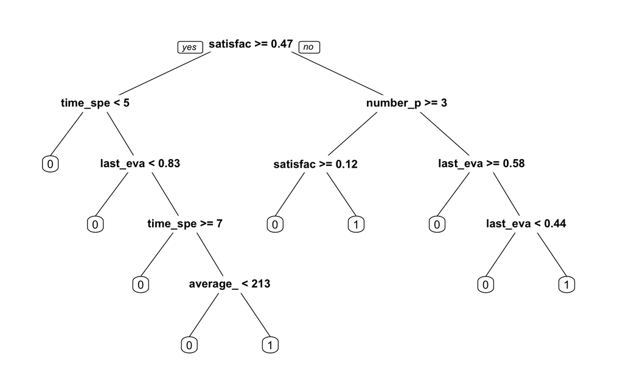

```r
prp(classTree,
    cex = .8)
```

Decision Trees can easily *overfit* because of the intrinsinc complexity of the model. *Pruning* is one of the methods to prevent the Decision Tree for overfitting: we *prune* the tree by relying on the *complexity parameter (cp)* to discard the branches that were developed to fit potentially idiosyncratic information present in the data. The CP (complexity parameter) is used to control tree growth: if the *cost of adding a variable* is higher then the value of CP then tree growth stops.

The CP parameters has to do with *an internal cross-validation procedure* performed by {Rpart} during the training of a Decision Tree model (to be explained in our live session).

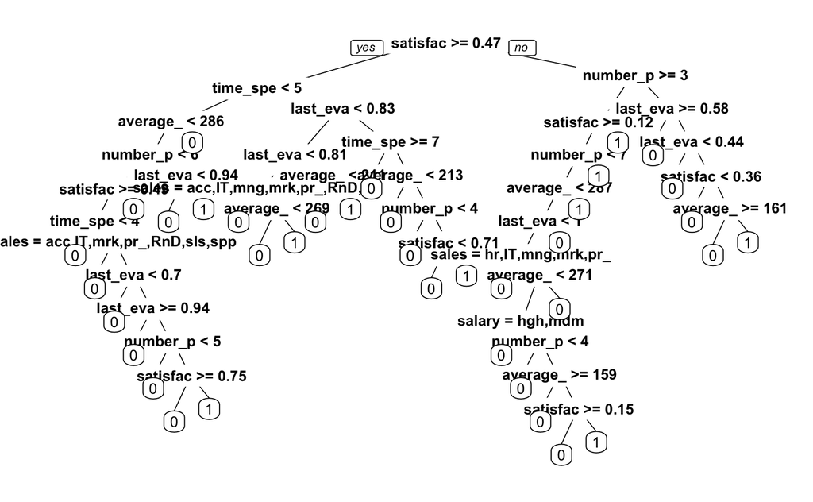

```r
# - Base Model
classTree <- rpart(left ~ .,
                   data = train,
                   method = "class",
                   control = rpart.control(cp = 0))
# - Inspect model:
prp(classTree,
    cex = .8)
```

```r
# - Examine the complexity plot
cptable <- as.data.frame(classTree$cptable)
print(cptable)
```

|  | CP | nsplit | rel error | xerror | xstd |
| --- | --- | --- | --- | --- | --- |
| 1 | 2.250567e-01 | 0 | 1.00000000 | 1.0000000 | 0.020858371 |
| 2 | 1.913265e-01 | 1 | 0.77494331 | 0.7749433 | 0.018977523 |
| 3 | 7.993197e-02 | 3 | 0.39229025 | 0.3922902 | 0.014216205 |
| 4 | 4.308390e-02 | 5 | 0.23242630 | 0.2380952 | 0.011291667 |
| 5 | 3.968254e-02 | 6 | 0.18934240 | 0.2046485 | 0.010511569 |
| 6 | 1.814059e-02 | 7 | 0.14965986 | 0.1575964 | 0.009277195 |
| 7 | 1.133787e-02 | 8 | 0.13151927 | 0.1366213 | 0.008659632 |
| 8 | 7.369615e-03 | 9 | 0.12018141 | 0.1258503 | 0.008322013 |
| 9 | 6.235828e-03 | 10 | 0.11281179 | 0.1230159 | 0.008230555 |
| 10 | 4.535147e-03 | 11 | 0.10657596 | 0.1122449 | 0.007872108 |

[output cut: 8 more lines]

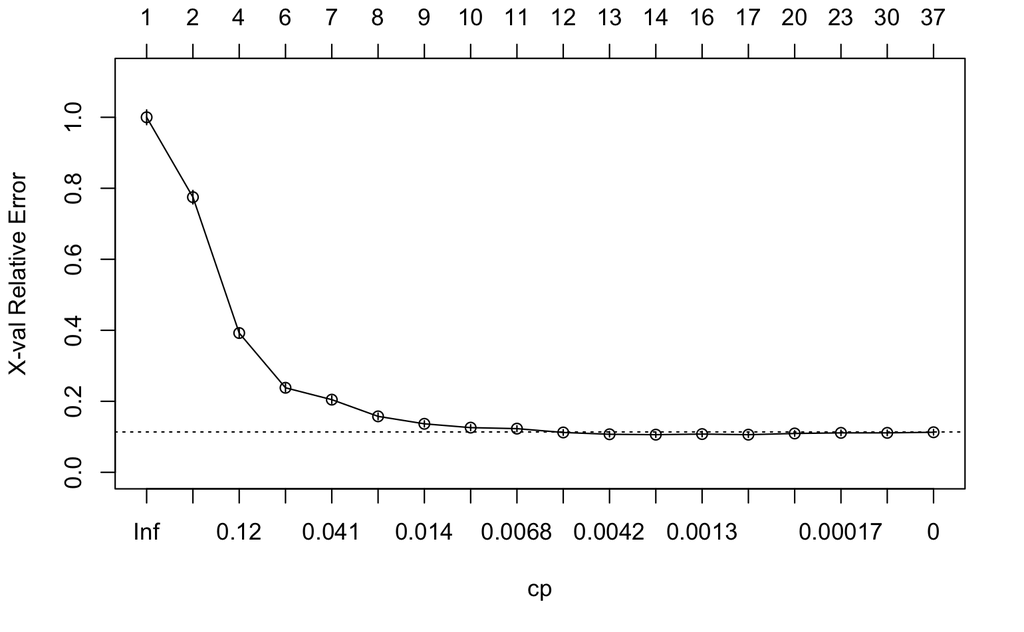

```r
plotcp(classTree)
```

The one with least **cross-validated error (xerror)** is the optimal value of CP.

```r
cptable[which.min(cptable$xerror), ]
```

|  | CP | nsplit | rel error | xerror | xstd |
| --- | --- | --- | --- | --- | --- |
| 12 | 0.001417234 | 13 | 0.09807256 | 0.1060091 | 0.007656007 |

ROC analysis for the base model:

```r
# - Base Model Accuracy
test$pred <- predict(classTree,
                     test,
                     type = "class")
# - silly, but I need to do this...
test$pred <- as.numeric(as.character(test$pred))
base_accuracy <- mean(test$pred == test$left)
print(paste0("Base model acc: ", base_accuracy))
```

```
[1] "Base model acc: 0.971266693646297"
```

```r
# - Base Model ROC
test$hit <- ifelse(test$pred == 1 & test$left == 1, T, F)
test$FA <- ifelse(test$pred == 1 & test$left == 0, T, F)
hitRate <- sum(test$hit)/length(test$hit)
print(paste0("Base model Hit rate: ", hitRate))
```

```
[1] "Base model Hit rate: 0.222851746931067"
```

```r
FARate <- sum(test$FA)/length(test$FA)
print(paste0("Base model FA rate: ", FARate))
```

```
[1] "Base model FA rate: 0.0078240928099285"
```

```r
test$miss <- ifelse(test$pred == 0 & test$left == 1, T, F)
missRate <- sum(test$miss)/length(test$miss)
print(paste0("Base model Miss rate: ", missRate))
```

```
[1] "Base model Miss rate: 0.0209092135437745"
```

```r
# - Prune the classTree based on the optimal cp value
optimal_cp <- cptable$CP[which.min(cptable$xerror)]
classTree_prunned <- prune(classTree,
                           cp = optimal_cp)
```

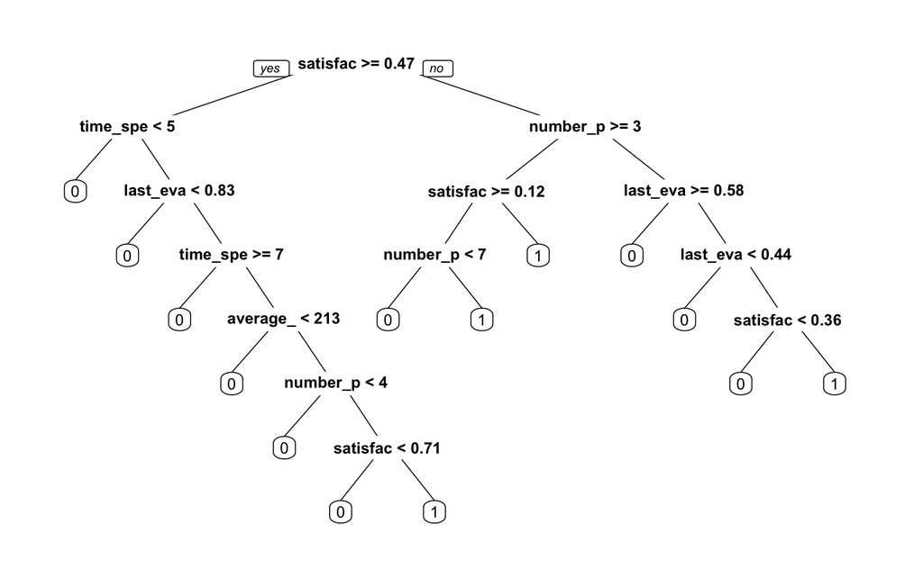

```r
prp(classTree_prunned,
    cex = .75)
```

```r
# - The accuracy of the pruned tree
test$pred <- predict(classTree_prunned,
                     test,
                     type = "class")
accuracy_postprun <- mean(test$pred == test$left)
print(paste0("Pruned model acc: ", accuracy_postprun))
```

```
[1] "Pruned model acc: 0.971131795494402"
```

```r
# - Pruned Model ROC
test$hit <- ifelse(test$pred == 1 & test$left == 1, T, F)
test$FA <- ifelse(test$pred == 1 & test$left == 0, T, F)
hitRate <- sum(test$hit)/length(test$hit)
print(paste0("Pruned Hit rate: ", hitRate))
```

```
[1] "Pruned Hit rate: 0.219614191285579"
```

```r
FARate <- sum(test$FA)/length(test$FA)
print(paste0("Pruned FA rate: ", FARate))
```

```
[1] "Pruned FA rate: 0.00472143531633617"
```

```r
test$miss <- ifelse(test$pred == 0 & test$left == 1, T, F)
missRate <- sum(test$miss)/length(test$miss)
print(paste0("Pruned Miss rate: ", missRate))
```

```
[1] "Pruned Miss rate: 0.0241467691892621"
```

```r
test$CR <- ifelse(test$pred == 0 & test$left == 0, T, F)
CRRate <- sum(test$CR)/length(test$CR)
print(paste0("Pruned CR rate: ", CRRate))
```

```
[1] "Pruned CR rate: 0.751517604208822"
```

For pruning with {rpart} Decison Trees in R, see the following Stack Overflow discussion: [Selecting cp value for decision tree pruning using rpart](https://stackoverflow.com/questions/37721047/selecting-cp-value-for-decision-tree-pruning-using-rpart).

### Further Readings

- [The Elements of Statistical Learning, Hastie, T., Tibshirani, R. & Friedman, J., 12th printing with corrections and table of contents, Jan 2017, Chapter 9.2 Tree-Based Methods)](https://web.stanford.edu/~hastie/ElemStatLearn/printings/ESLII_print12_toc.pdf)
- [An Introduction to Recursive Partitioning Using the RPART Routines, Terry M. Therneau, Elizabeth J. Atkinson, Mayo Foundation, April 11, 2019](https://cran.r-project.org/web/packages/rpart/vignettes/longintro.pdf)

Goran S. Milovanović

DataKolektiv, 2020/21

contact: goran.milovanovic@datakolektiv.com

License: [GPLv3](http://www.gnu.org/licenses/gpl-3.0.txt) This Notebook is free software: you can redistribute it and/or modify it under the terms of the GNU General Public License as published by the Free Software Foundation, either version 3 of the License, or (at your option) any later version. This Notebook is distributed in the hope that it will be useful, but WITHOUT ANY WARRANTY; without even the implied warranty of MERCHANTABILITY or FITNESS FOR A PARTICULAR PURPOSE. See the GNU General Public License for more details. You should have received a copy of the GNU General Public License along with this Notebook. If not, see http://www.gnu.org/licenses/.